# Leaflet: Online Mapping in R

Robin Lovelace - Jan 31/15

2019-05-30

# 1 Purpose

To explore the creation of interactive online maps using the Leaflet map widget. `leaflet` package in R combines the leaflet Open-Source JavaScript library with htmlwidgets. It also works with the R `shiny` package.

The base for this exercise is work of Dr. Robin Lovelace at http://robinlovelace.net/r/2015/02/01/leaflet-r-package.html. His web site contains a wealth of mapping resources in R and other open-source software.

Top

## 1.1 Set up libraries and data

```r
# required libraries
library(leaflet)
library(png)
library(grid)
library(rgdal)
```

# 2 First web map

One line of code generates an interactive world map and displays it witin R-Studio. Map first appears blank. Select the + control to bring it up.

```r
# Plot a default web map (brackets force display of the result)
(m <- leaflet() %>% addTiles())
```

[interactive chart not shown]

The following capture illustrates details at maximum zoom.

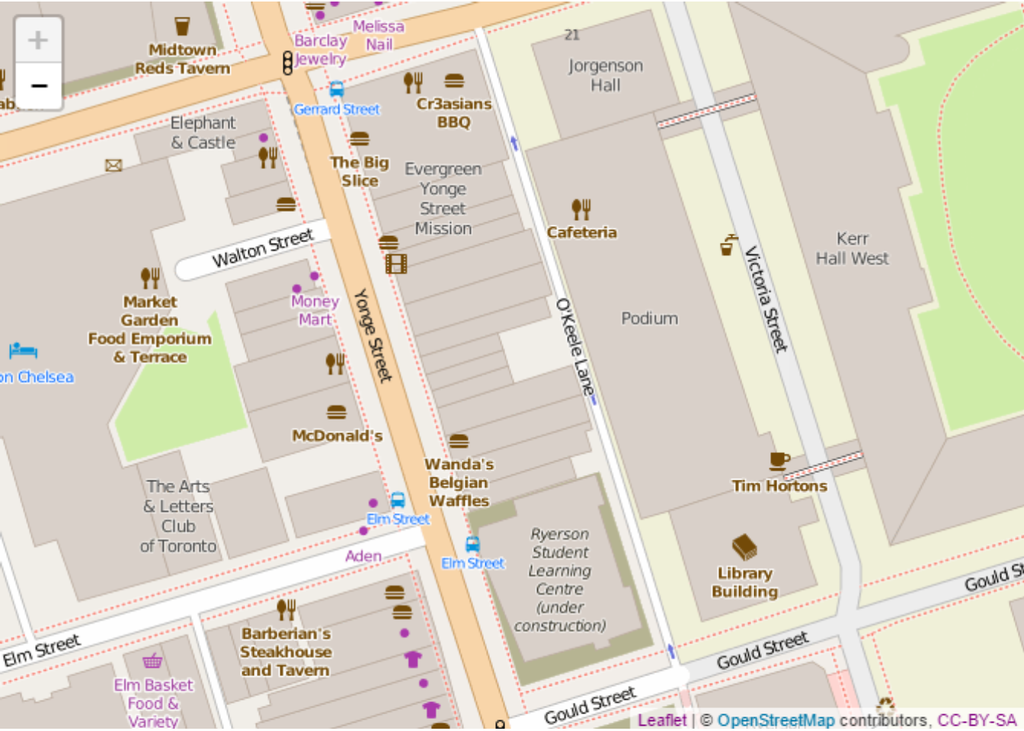

```r
# Ryerson University campus downtown Toronto
img <- readPNG("./img/map-Toronto-Ryerson.png")
grid.raster(img)
```

top

## 2.1 Adding features with %>%

`Leaflet` applies the newly available `%>%` piping operator (see dev notes below), making it easy to sequentially add settings and functions without using complex nested brackets.

For example, adding a location to our map `m` generated above is done by piping the map into the package’s `setView()` function. The arguments of this function require latitude and longitude.

### 2.1.1 Locating latitude and longitude

To locate coordinates for a place or specific address (or to convert from known lat long) use the resources at [latlong.net](http://www.latlong.net/).

In the example below we zoom to the max into Montreal’s St. Viateur Bagel Bakery.

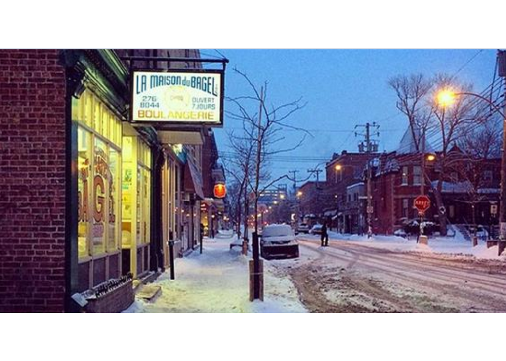

```r
img <- readPNG("./img/StViateurBagel.png")
grid.raster(img)
```

```r
 # set centre and zoom for world's best bagel
m %>% setView(lng = -73.602111, lat = 45.522435, zoom = 18)
```

[interactive chart not shown]

top

Add markers and popup to the map by applyng the piping operator:

```r
 (m2 <- m %>%
    setView(-73.602111, 45.522435, 14)  %>% # zoom out from above
    addMarkers(-73.587434, 45.515176)  %>%  # add marker
    addPopups(-73.602111, 45.522435, popup = "St. Viateur Bagels")  %>% # popup
    # add circles 1st runif sets min/max longitude, 2nd sets long, 3rd sets radius
    addCircles(color = "red", runif(10, -73.61, -73.57), runif(10, 45.515, 45.53), runif(10, 40, 125)))
```

[interactive chart not shown]

top

# 3 Adding data

In the above example we added random data in the shape of circles. Now we explore real data. There are 3 options in `leaflet`:

- data in the form of a lat/long matrix or data frame in base R
- data from the `sp` package (SpatialPoint, SpatialPolygons, others)
- data from the `maps` package

## 3.1 Hiking the mountain

Growing up next to Mt. Royal, the mountain provides a life long love of public parks. Let’s plot a hike. The data comes from http://www.wikiloc.com/wikiloc/view.do?id=3733830, a public source requiring a free account for downloading.

To load this data requires the `rgdal` package.

```r
# load hiking data as a SpatialLinesDataFrame
mtroyal <- readOGR("./data/mt-royal-montreal.gpx", layer ="tracks")
```

```r
# display in leaflet, changing centre of map and zooming out to display more
m2 %>%
  setView(-73.602111, 45.515, 13) %>% # map location
  addPolylines(data = mtroyal, color = "red", weight = 4)
```

[interactive chart not shown]

Top

# 4 Shiny Integration

Leaflet development comes from the same team who did `shiny`. The example below demonstrates the integration of both. Shiny does not display within an rmarkdown/html page. To view as an independent web page, copy/paste code below to the R console.

```r
library(shiny)
library(leaflet)
shinyApp(
  ui = fluidPage(leafletOutput('myMap')),
  server = function(input, output) {

    shef2leeds <- readOGR("./data/shef2leeds.gpx", layer = "tracks")

    map = leaflet() %>% addTiles() %>% setView(-1.5, 53.4, 9) %>%
      addPolylines(data = shef2leeds, color = "red", weight = 4)
    output$myMap = renderLeaflet(map)
  }
)
```

```
##
## Listening on http://127.0.0.1:4471
```

```
## Error in ogrInfo(dsn = dsn, layer = layer, encoding = encoding, use_iconv = use_iconv,  :
##   Cannot open data source
```

Top

# 5 References

http://www.r-bloggers.com/the-leaflet-package-for-online-mapping-in-r/ on Jan 31/15  
http://robinlovelace.net/r/2015/02/01/leaflet-r-package.html  
http://leafletjs.com/  
http://www.latlong.net/  
http://www.wikiloc.com/wikiloc/view.do?id=3733830

top

# 6 Dev Notes

20190530 - review, minor edits, re-run  
20190212 - on re-run had to reinstall leaflet using devtools and github to avoid errs; Within RStudio, a keyboard short-cut `Ctl+Shift+M` produces the pipe operator `%>%`

```
May you do good and not evil.
May you find forgiveness for yourself and forgive others.
May you share freely, never taking more than you give.
CC ^[<a href="http://creativecommons.org/licenses/by-sa/4.0/" target="_blank">CC-by-SA 4.0</a>]
```